# Starch Content Analysis

Jimmy Larson

10/29/2020

## Introduction

This is a file that describes the process for analyzing fruit starch content for a preharvest drop study conducted from Aug.-Oct. 2020 on Red Delicious apples. 12 total fruit from the outside 2 trees per plot these fruit had their internal ethylene concentrations and firmness measured, juice from each apple in a treatment by rep combination was collected and had their brix measured using a refractometer. Following firmness, each fruit was cut in half equatorially and dipped into a starch iodine solution. Staining pattern was evaluated on a 1-8 scale:

- August 28
- September 1
- September 7
- September 14
- September 21
- September 29
- October 12

Below is the Cornell Starch Iodine Staining index…

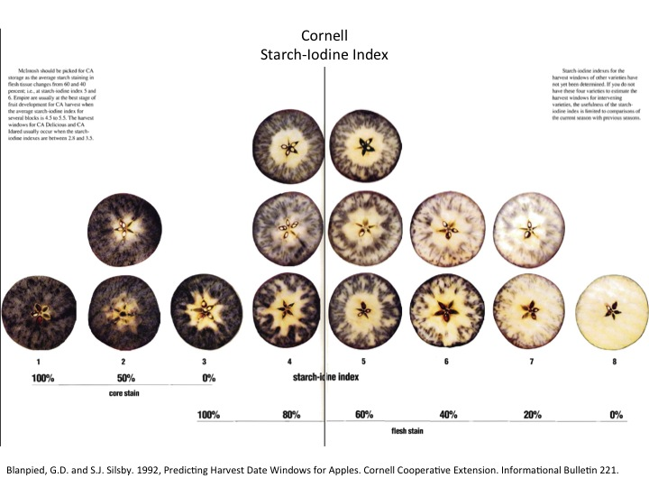

Cornell Starch Iodine Staining index

## Join Data

Data was joined for each measurement date starting with the first, Aug. 28

```r
starchAug28 %>%
  rename(starchAug28 = starch) %>%
  left_join(starchSep1) %>%
  rename(starchSep1 = starch) %>%
  left_join(starchSep7) %>%
  rename(starchSep7 = stach) %>%
  left_join(starchSep14) %>%
  rename(starchSep14 = starch) %>%
  left_join(starchSep21) %>%
  rename(starchSep21 = starch) %>%
  left_join(starchSep29) %>%
  rename(starchSep29 = starch) %>%
  select(treatment, rep, fruit, starchAug28, starchSep1, starchSep7, starchSep14, starchSep21, starchSep29) %>%
  left_join(starchOct12) %>%
  rename(starchOct12 = starch) %>%
  select(treatment, rep, fruit, starchAug28, starchSep1, starchSep7, starchSep14, starchSep21, starchSep29,
         starchOct12) -> starch
```

## Explore Data

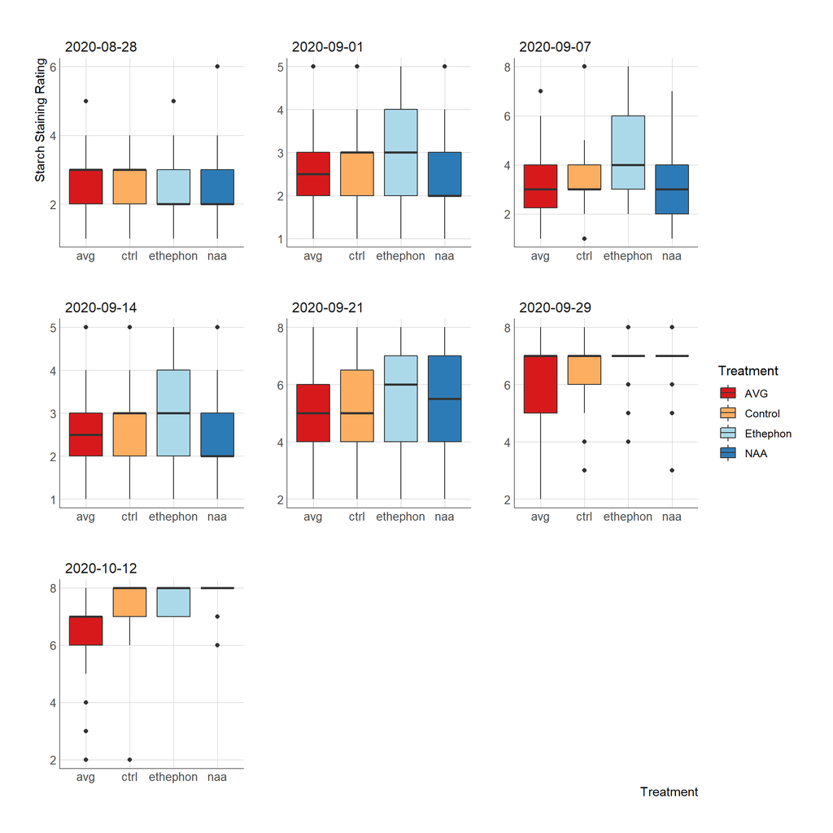

## ANOVA Assumptions

### ANOVA Model

```r
starchAug28.aov <- aov(starchAug28 ~ treatment, data = starch)
```

### Normality Check

```r
starchAug28.resid <- residuals(object = starchAug28.aov)
shapiro.test(x = starchAug28.resid)
```

### Homogeneity of Variance Check

```r
leveneTest(starchAug28 ~ treatment, data = starch)
```

### **Aug. 28**

Shaprio-Wilkes test was significant, but levene’s test was not…

```
##
##  Shapiro-Wilk normality test
##
## data:  starchAug28.resid
## W = 0.93291, p-value = 6.367e-09
```

```
## Levene's Test for Homogeneity of Variance (center = median)
##        Df F value Pr(>F)
## group   3  0.6316 0.5953
##       233
```

### **Sep. 1**

Shaprio-Wilkes test was significant, but levene’s test was not…

```
##
##  Shapiro-Wilk normality test
##
## data:  starchSep1.resid
## W = 0.95585, p-value = 1.305e-06
```

```
## Levene's Test for Homogeneity of Variance (center = median)
##        Df F value Pr(>F)
## group   3   0.293 0.8304
##       231
```

### **Sep. 7**

Both tests were significant…

```
##
##  Shapiro-Wilk normality test
##
## data:  starchSep7.resid
## W = 0.93799, p-value = 2.042e-08
```

```
## Levene's Test for Homogeneity of Variance (center = median)
##        Df F value   Pr(>F)
## group   3  4.1387 0.006983 **
##       231
## ---
## Signif. codes:  0 '***' 0.001 '**' 0.01 '*' 0.05 '.' 0.1 ' ' 1
```

### **Sep. 14**

Shaprio-Wilkes test was significant, but levene’s test was not…

```
##
##  Shapiro-Wilk normality test
##
## data:  starchSep14.resid
## W = 0.95585, p-value = 1.305e-06
```

```
## Levene's Test for Homogeneity of Variance (center = median)
##        Df F value Pr(>F)
## group   3   0.293 0.8304
##       231
```

### **Sep. 21**

Shaprio-Wilkes test was significant, but levene’s test was not…

```
##
##  Shapiro-Wilk normality test
##
## data:  starchSep21.resid
## W = 0.96609, p-value = 2.471e-05
```

```
## Levene's Test for Homogeneity of Variance (center = median)
##        Df F value Pr(>F)
## group   3  1.3893 0.2468
##       228
```

### **Sep. 29**

Both tests were significant…

```
##
##  Shapiro-Wilk normality test
##
## data:  starchSep29.resid
## W = 0.84486, p-value = 2.144e-14
```

```
## Levene's Test for Homogeneity of Variance (center = median)
##        Df F value   Pr(>F)
## group   3  4.8249 0.002826 **
##       225
## ---
## Signif. codes:  0 '***' 0.001 '**' 0.01 '*' 0.05 '.' 0.1 ' ' 1
```

### **Oct. 12**

Both tests were significant…

```
##
##  Shapiro-Wilk normality test
##
## data:  starchOct12.resid
## W = 0.68083, p-value < 2.2e-16
```

```
## Levene's Test for Homogeneity of Variance (center = median)
##        Df F value Pr(>F)
## group   3  3.6563 0.0133 *
##       219
## ---
## Signif. codes:  0 '***' 0.001 '**' 0.01 '*' 0.05 '.' 0.1 ' ' 1
```

## Treatment Separation

### **Aug. 28**

```
##
##  Kruskal-Wallis rank sum test
##
## data:  starchAug28 by treatment
## Kruskal-Wallis chi-squared = 7.4038, df = 3, p-value = 0.06008
```

```
##
##  Pairwise comparisons using Wilcoxon rank sum test
##
## data:  starch$starchAug28 and starch$treatment
##
##          avg   ctrl  ethephon
## ctrl     0.703 -     -
## ethephon 0.490 0.627 -
## naa      0.094 0.094 0.184
##
## P value adjustment method: BH
```

### **Sep. 1**

```
##
##  Kruskal-Wallis rank sum test
##
## data:  starchSep1 by treatment
## Kruskal-Wallis chi-squared = 10.815, df = 3, p-value = 0.01277
```

```
##
##  Pairwise comparisons using Wilcoxon rank sum test
##
## data:  starch$starchSep1 and starch$treatment
##
##          avg   ctrl  ethephon
## ctrl     0.464 -     -
## ethephon 0.027 0.161 -
## naa      0.651 0.291 0.016
##
## P value adjustment method: BH
```

### **Sep. 7**

```
##
##  Kruskal-Wallis rank sum test
##
## data:  starchSep7 by treatment
## Kruskal-Wallis chi-squared = 26.269, df = 3, p-value = 8.377e-06
```

```
##
##  Pairwise comparisons using Wilcoxon rank sum test
##
## data:  starch$starchSep7 and starch$treatment
##
##          avg     ctrl    ethephon
## ctrl     0.35552 -       -
## ethephon 8.8e-05 0.00043 -
## naa      0.96735 0.35552 0.00013
##
## P value adjustment method: BH
```

### **Sep. 14**

```
##
##  Kruskal-Wallis rank sum test
##
## data:  starchSep14 by treatment
## Kruskal-Wallis chi-squared = 10.815, df = 3, p-value = 0.01277
```

```
##
##  Pairwise comparisons using Wilcoxon rank sum test
##
## data:  starch$starchSep14 and starch$treatment
##
##          avg   ctrl  ethephon
## ctrl     0.464 -     -
## ethephon 0.027 0.161 -
## naa      0.651 0.291 0.016
##
## P value adjustment method: BH
```

### **Sep. 21**

```
##
##  Kruskal-Wallis rank sum test
##
## data:  starchSep21 by treatment
## Kruskal-Wallis chi-squared = 6.3528, df = 3, p-value = 0.09565
```

```
##
##  Pairwise comparisons using Wilcoxon rank sum test
##
## data:  starch$starchSep21 and starch$treatment
##
##          avg  ctrl ethephon
## ctrl     0.82 -    -
## ethephon 0.11 0.12 -
## naa      0.66 0.72 0.33
##
## P value adjustment method: BH
```

### **Sep. 29**

```
##
##  Kruskal-Wallis rank sum test
##
## data:  starchSep29 by treatment
## Kruskal-Wallis chi-squared = 18.678, df = 3, p-value = 0.0003186
```

```
##
##  Pairwise comparisons using Wilcoxon rank sum test
##
## data:  starch$starchSep29 and starch$treatment
##
##          avg     ctrl    ethephon
## ctrl     0.00497 -       -
## ethephon 0.00072 0.76513 -
## naa      0.00118 0.76513 0.94301
##
## P value adjustment method: BH
```

### **Oct. 12**

```
##
##  Kruskal-Wallis rank sum test
##
## data:  starchOct12 by treatment
## Kruskal-Wallis chi-squared = 57.378, df = 3, p-value = 2.134e-12
```

```
##
##  Pairwise comparisons using Wilcoxon rank sum test
##
## data:  starch$starchOct12 and starch$treatment
##
##          avg     ctrl ethephon
## ctrl     4.6e-08 -    -
## ethephon 4.6e-08 0.66 -
## naa      2.3e-09 0.39 0.22
##
## P value adjustment method: BH
```

## Figure

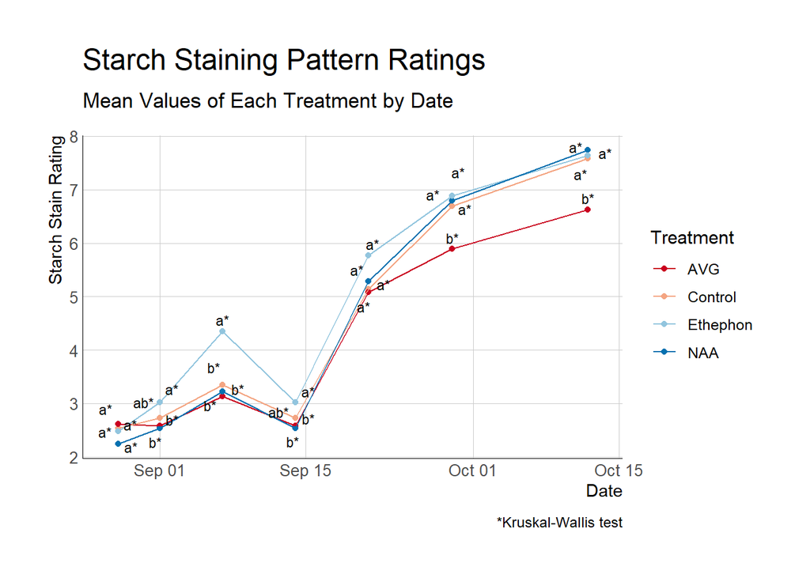